# Marginal Standardization and Visualizing Logistic Regression Through Time

Sven Halvorson

2020-03-10

After working on some problems involving trying to visualize logistic models, my teammate gave me this [this paper](https://pdfs.semanticscholar.org/6807/8f0a3839b8d89cd25a964c03a571545793cb.pdf?_ga=2.241765888.362902951.1583340021-1552661845.1583340021). It did help improve the plots I was making but there are some questions left unanswered. My goal for this document is to:

1. Describe marginal standardization & give a simple example.
2. Demonstrate a calculation for a logistic model with multiple categorical and continuous predictors.
3. Simulate a data set and look at how the correlation, incidence, and number of predictors affect graphs of a continuous predictor in a logistic model.
4. Try to draw some conclusions about how to best create graphs for segmented regression models with binary outcomes.

### Description of marginal standardization

As a preliminary step, let’s go through the example the authors present of using a logistic model on a population where half the participants are men and half women. Unexposed women have the even 50% of the time and unexposed men have it 99% of the time:

| female | outcome | n |
| --- | --- | --- |
| 0 | 0 | 1 |
| 0 | 1 | 99 |
| 1 | 0 | 50 |
| 1 | 1 | 50 |

Now we make the model:

```r
gender_mod = glm(
  outcome ~  female,
  family = 'binomial',
  data = gender_dat
)
```

**Method 1: Marginal standardization**

We predict the probability for each gender, then weight them according to their frequency in the data set.

```r
marg_prob = predict.glm(
  object = gender_mod,
  newdata = tibble(female = c(0,1)),
  type = 'response'
)

marg_prob = sum(
  c(0.5, 0.5)*marg_prob
)
round(100*marg_prob, 1)
```

```
## [1] 74.5
```

**Method 2: Prediction at the mode of gender**

The authors suggest another method which is predicts at the mode of all the categorical predictors. I didn’t even consider this as it seems obvious that it’s going to completely fail unless the population is very homogeneous. It’s also not clear how you would even use that in the case of a 50-50 split like our example. NEXT!

**Method 3: Prediction at the mean of gender**

```r
mean_prob = predict.glm(
  object = gender_mod,
  newdata = tibble(female = 0.5),
  type = 'response'
) %>%
 unname()

round(100*mean_prob, 1)
```

```
## [1] 90.9
```

So we end up with a wildly different conclusion. What’s the most intuitive way to do this without all this fancy schmantzy logistic regression? Just use the law of total probability:

```r
ez_calc = 0.5*0.99 + 0.5*0.5
round(100*ez_calc, 1)
```

```
## [1] 74.5
```

This gives the exact same result as the marginal standardization.

So why is this happening? The author doesn’t give a very satisfying answer to *why* prediction at the mean doesn’t work. They simply state that we’re making predictions from impossible data points. There are no 50% females (at least in the data set).

The most insightful thing that I’ve been able to come up with as to why our intuition is confused is just looking at the algebra. If we compute the overall odds we get this:

$$\textrm{Overall Odds}\frac{99+50}{1+50} = 2.92$$

Computing the odds using method 3 starts with the logistic model:
$$\log(\frac{p}{1-p})=\beta_0+\beta_1(\textrm{female = 1})$$
$$\frac{p}{1-p}=e^{\beta_0+\beta_1(\textrm{female = 1})}$$
If we substitute in 0.5 for female, we get this:
$$\frac{p}{1-p}=e^{\beta_0+\beta_1\cdot0.5}=e^{\beta_0}\sqrt{e^{\beta_1}}$$
So this would be saying that to compute the overall odds, we take the odds of the outcome for men and multiply it by the square root of the odds ratio of women to men. Note the square root is only because we have a 50-50 split of women to men.

$$\frac{p}{1-p}=\frac{99}{1}\sqrt{\frac{\frac{50}{50}}{\frac{99}{1}}} = 9.95$$
This gives us the same predicted probability as the code above:

$$\frac{9.95}{1+9.95}=0.909$$

It just seems hard to explain why you would want to exponentiate the odds ratio for the second group by the relative frequency of that group in order to compute the overall odds. This isn’t that satisfying either but it does at least make prediction at the mean (method 3) seem more bizarre.

Framing it this way does let us see how, as Muller notes, having a low correlation between the predictor and outcome will cause this to be very similar to the marginal method. If $e^{\beta_1}\approx1$:

$$\frac{p}{1-p}=e^{\beta_0+\beta_1\cdot P(X=1)} \approx e^{\beta_0}\cdot 1^{P(X =1)}\approx e^{\beta_0}$$
And if the relationship between $X$ and $Y$ is very weak, the odds of $Y$ should be about the same when $X = 0$ as when $X = 1$.

Another question we might ask is ‘does this matter for continuous outcomes?’ The answer to this is a clean ‘no’. If you have a model like:

$$Y=\beta_0+\beta_1(\textrm{female = 1})$$
Where Y is a continuous variable, then we predicting with marginal standardization gives:

$$\hat{Y}=P(\textrm{female = 0})\beta_0 + P(\textrm{female = 1})[\beta_0+\beta_1]$$
And this is exactly what you would get through prediction at the mean:

$$P(\textrm{female = 0})\beta_0 + P(\textrm{female = 1})[\beta_0+\beta_1]= \beta_0 + P(\textrm{female =1})\beta_1$$

### Computing marginally adjusted probabilities with larger models

Computing the marginally adjusted probability is pretty easy with one predictor but programming the calculation for a more complex model might not seem so simple. Here I’ll show an example with a variation on the `nycflights13:flights` data set that you can get through the corresponding library. It has a list of a lot of flights out of NYC in 2013. We’ll make our outcome variable whether or not the flight departed late and use the flight distance, whether the scheduled departure was in the afternoon, the departing airport, and the carrier as predictors. I’ve dropped observations with a missing outcome or predictor. I’ve also made dummies for the airport and carrier where Newark and Endeavor Air are their respective reference categories.

Here’s some of the data set we’ll use:

| late | distance | pm | origin_LGA | origin_JFK | carrier_AA | carrier_B6 | … | carrier_YV |
| --- | --- | --- | --- | --- | --- | --- | --- | --- |
| 1 | 319 | 0 | 0 | 0 | 0 | 0 |  | 0 |
| 1 | 1416 | 0 | 1 | 0 | 0 | 0 |  | 0 |
| 1 | 116 | 1 | 0 | 0 | 0 | 0 |  | 0 |
| 0 | 888 | 0 | 1 | 0 | 0 | 0 |  | 0 |
| 0 | 1010 | 1 | 1 | 0 | 0 | 0 |  | 0 |
| 1 | 273 | 1 | 0 | 1 | 0 | 1 |  | 0 |
| 0 | 583 | 1 | 0 | 0 | 0 | 0 |  | 0 |
| 1 | 2133 | 1 | 0 | 0 | 0 | 0 |  | 0 |
| 1 | 2586 | 0 | 0 | 1 | 0 | 0 |  | 0 |
| 0 | 1028 | 0 | 0 | 1 | 0 | 1 |  | 0 |

Here’s the model we’ll use:

```r
form = flights_ex %>%
  select(-late) %>%
  colnames() %>%
  paste(collapse = ' + ')

form = paste0('late ~ ', form)

flight_mod = glm(
  as.formula(form),
  family = 'binomial',
  data = flights_ex
)
```

```r
round(100*mean(flights_ex[['late']]), 1)
```

```
## [1] 39.1
```

To use the marginal standardization method, we will use the law of total probability again. There are many possible combinations of the categorical variables (3 airports, am or pm, and 16 carriers) that we have to sum across. Start by computing the relative frequencies of each combination within our data set. Here is a sample 10 combinations:

```r
rel_freq = flights_ex %>%
  select(
    pm,
    matches('origin_'),
    matches('carrier_')
  ) %>%
  group_by_all() %>%
  count() %>%
  ungroup() %>%
  mutate(
    rel_freq = n/sum(n)
  )
```

| pm | origin_LGA | origin_JFK | carrier_AA | carrier_B6 | … | carrier_YV | n | rel_freq |
| --- | --- | --- | --- | --- | --- | --- | --- | --- |
| 1 | 0 | 0 | 0 | 0 |  | 0 | 28,015 | 0.085 |
| 0 | 1 | 0 | 1 | 0 |  | 0 | 7,049 | 0.021 |
| 1 | 0 | 0 | 0 | 0 |  | 0 | 6 | 0.000 |
| 1 | 0 | 0 | 0 | 0 |  | 0 | 702 | 0.002 |
| 1 | 1 | 0 | 0 | 0 |  | 0 | 3,932 | 0.012 |
| 1 | 0 | 1 | 0 | 0 |  | 0 | 13,796 | 0.042 |
| 0 | 0 | 0 | 0 | 0 |  | 0 | 959 | 0.003 |
| 1 | 0 | 0 | 0 | 0 |  | 0 | 25,434 | 0.077 |
| 1 | 0 | 1 | 0 | 1 |  | 0 | 26,460 | 0.081 |
| 0 | 0 | 1 | 0 | 0 |  | 0 | 1,399 | 0.004 |

Now we take this matrix, add on the means of the continuous variables, and then make the predictions from the model:

```r
rel_freq = rel_freq %>%
  mutate(
    distance = mean(flights_ex[['distance']])
  )
rel_freq['predicted_prob'] = predict.glm(
  flight_mod,
  rel_freq,
  type = 'response'
)
```

| distance | pm | origin_LGA | origin_JFK | carrier_AA | carrier_B6 | … | carrier_YV | n | rel_freq | predicted_prob |
| --- | --- | --- | --- | --- | --- | --- | --- | --- | --- | --- |
| 1048.571 | 1 | 0 | 0 | 0 | 0 |  | 0 | 28,015 | 0.085 | 0.565 |
| 1048.571 | 0 | 1 | 0 | 1 | 0 |  | 0 | 7,049 | 0.021 | 0.182 |
| 1048.571 | 1 | 0 | 0 | 0 | 0 |  | 0 | 6 | 0.000 | 0.353 |
| 1048.571 | 1 | 0 | 0 | 0 | 0 |  | 0 | 702 | 0.002 | 0.489 |
| 1048.571 | 1 | 1 | 0 | 0 | 0 |  | 0 | 3,932 | 0.012 | 0.527 |
| 1048.571 | 1 | 0 | 1 | 0 | 0 |  | 0 | 13,796 | 0.042 | 0.410 |
| 1048.571 | 0 | 0 | 0 | 0 | 0 |  | 0 | 959 | 0.003 | 0.211 |
| 1048.571 | 1 | 0 | 0 | 0 | 0 |  | 0 | 25,434 | 0.077 | 0.561 |
| 1048.571 | 1 | 0 | 1 | 0 | 1 |  | 0 | 26,460 | 0.081 | 0.484 |
| 1048.571 | 0 | 0 | 1 | 0 | 0 |  | 0 | 1,399 | 0.004 | 0.207 |

There are some real variation in the predicted probabilities between these combinations categorical variables. This difference will make the marginal method better than the means method.

Final step is to just compute the weighted average of these predicted probabilities:

```r
rel_freq %>%
  summarize(
    marg_predicted_prob = 100*sum(rel_freq*predicted_prob)
  )
```

```
## # A tibble: 1 x 1
##   marg_predicted_prob
##                 <dbl>
## 1                39.1
```

It’s exactly the same as the computation without the model. What does the prediction at the means method yield? First compute the means of each variable:

```r
flight_means = flights_ex %>%
  select(
    distance,
    pm,
    matches('origin_'),
    matches('carrier_')
  ) %>%
  summarize_all(
    mean
  )
```

| distance | pm | origin_LGA | origin_JFK | carrier_AA | carrier_B6 | … | carrier_YV |
| --- | --- | --- | --- | --- | --- | --- | --- |
| 1048.571 | 0.608 | 0.309 | 0.333 | 0.098 | 0.165 |  | 0.002 |

Then use this as your only data point to predict:

```r
predict.glm(
  flight_mod,
  flight_means,
  type = 'response'
) %>%
  unname()
```

```
## [1] 0.3808039
```

This prediction is off by about 1.1 percentage points. My suspicion is that the more categorical predictors we use and the more heavily they are correlated with the outcome, the large the gap between these two methods will become. As I mentioned before, the reason that this topic came to my attention was that I was trying to plot some logistic models with confounder adjustments and they ended up looking very poor. The difference between these two methods was proposed as a possible reason why the plots didn’t fit well. In this case, however, the difference is small enough it doesn’t much matter. Here is the proportion of flights leaving late aggregated by distance percentile plotted on a logit scale:

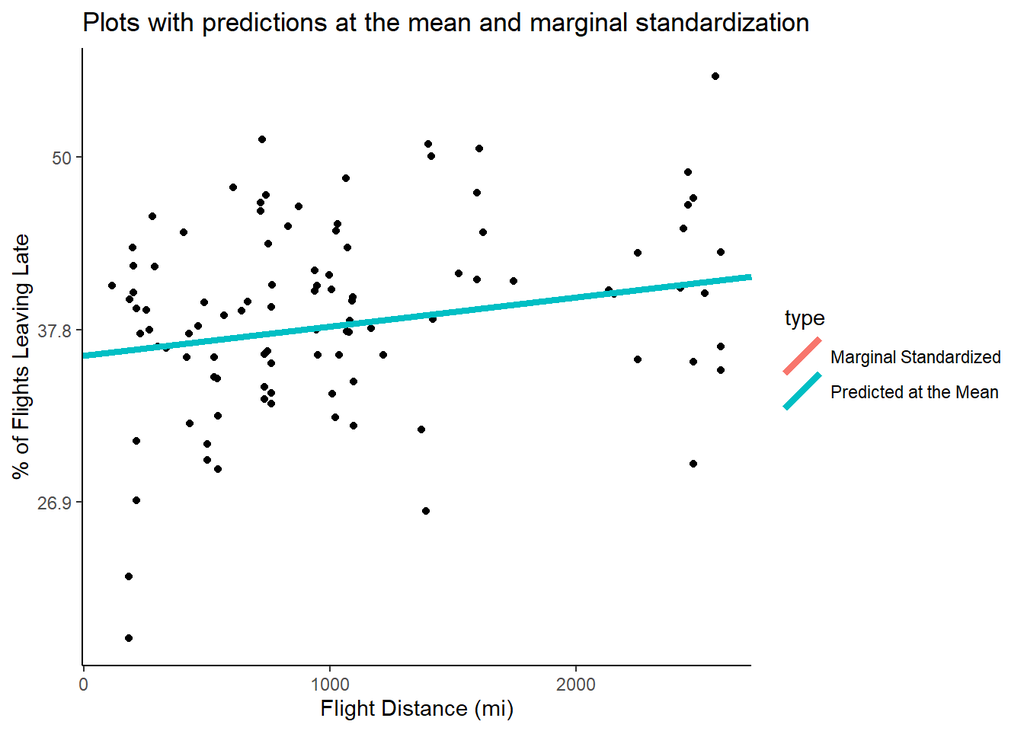

You might be wondering why you would even do this if I was able to just compute the probabilities without the models. We’ll look at some graphs in the next section but one reason is to compute other confounder adjusted summaries like a relative risk.

Let’s a compute the adjusted relative risk of leaving late between flights in the am vs pm. This time we’ll exclude the pm flag from our computations of the relative frequencies of each covariate pattern:

```r
rel_freq_pm = flights_ex %>%
  select(
    matches('origin_'),
    matches('carrier')
  ) %>%
  group_by_all() %>%
  count() %>%
  ungroup() %>%
  mutate(
    rel_freq = n/sum(n)
  )  %>%
  mutate(
    distance = mean(flights_ex[['distance']])
  ) %>%
  crossing(
    tibble(
      pm = 0:1
    )
  )


rel_freq_pm['predicted_prob'] = predict.glm(
  flight_mod,
  rel_freq_pm,
  type = 'response'
)

rel_freq_pm %>%
  group_by(pm) %>%
  summarize(
    predicted_prob = sum(rel_freq*predicted_prob)
  ) %>%
  pivot_wider(
    names_from = pm,
    values_from = predicted_prob,
    names_prefix = 'pm_'
  ) %>%
  mutate(
    RR = pm_1/pm_0
  )
```

```
## # A tibble: 1 x 3
##    pm_0  pm_1    RR
##   <dbl> <dbl> <dbl>
## 1 0.257 0.477  1.86
```

This is telling us that our confounder adjusted model predicts that you are 1.86 times as likely to leave late in the afternoon than in the morning.

### Plotting logistic regression

The previous discussion of marginal standardization demonstrated the proper way to compute summary statistics. While this was certainly worthwhile, it didn’t solve the main issue I was trying to fix. The difference between marginally standardized plots and plots with predictions at the mean were often similar and didn’t address the weirdness I frequently saw. As a result, I have questions about when exactly these plots seem to fail. Is any sort of cumulative effect of adding more total confounders? What kinds of correlations cause the graphics to look so ugly?

I’m a considerably better programmer than statistician so I think I’ll simulate a data set and do some experiment to try and address these questions. We’ll get a chance to try out this `simstudy` library that I saw on a blog. Here’s the [vignette](https://cran.r-project.org/web/packages/simstudy/vignettes/simstudy.html) for reference.

For this experiment I’m going to create an outcome variables with linear log odds changes through time with a medium incidence and a medium change through time. I’ve created roughly 1,000 observations for each of the 100 time points.

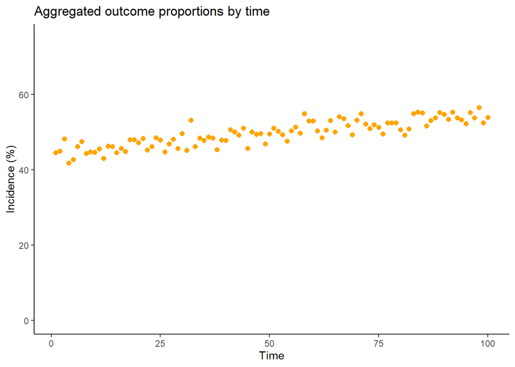

After creating the outcome and time variables, I created a lot of binary variables to act as covariates for our models. The types were:

1. **Not correlated with either the time or outcome**. I made sets with low, medium, and high incidence.
2. **Correlated with only the time variable**. These were also created in sets of low, medium, or high incidence. I also created them in batches of 20 where each successive iteration icreased the strength of the relationship with time by 5%.
3. **Correlated with both time and the predictor**. Here we again set the incidence at low, medium, or high and correlated with the outcome and time. The strength of the correlations to the outcome and time were again increased in increments of 5%.

A graph of the predictors that were of medium incidence and correlate with time only are depicted below:

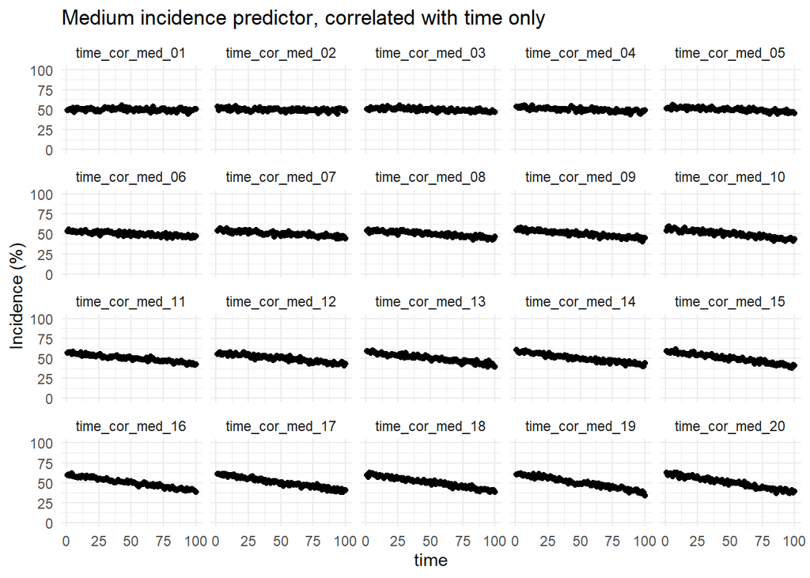

#### Uncorrelated predictors

The first thing I want to do is look at some graphs of what happens when you use uncorrelated predictors. We should probably think that this will not affect the shape of the graph very much because the effect on the outcome is constant through time. Here we’ll just look at a graph of the outcome vs time while we successively add in additional randomly selected predictors of any incidence that are not correlated with either the outcome or time:

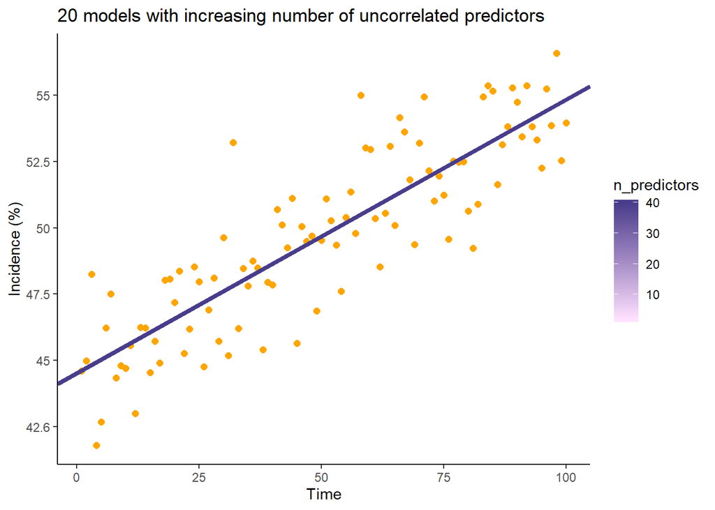

All of the lines are basically on top of each other indicating that these graphs aren’t really affected by the number of uncorrelated predictors in the model.

#### Time correlated predictors

Let’s do something similar here where we progressively add in stronger and stronger predictors that are correlated with the time variable only.

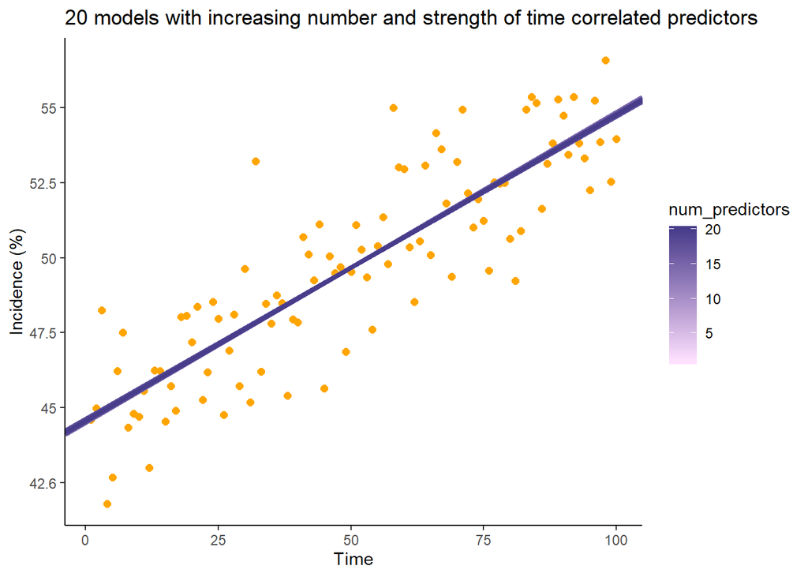

If you look very closely you can see some separation between the graphs but it’s sill quite minor.

#### Time and outcome correlated predictors

Finally, we’ll look at the binary predictors that are correlated with both time and the outcome. Here I’ve used only one binary predictor of medium incidence successively increased its strength. The unadjusted (time only) model is plotted in red. We can see that the unadjusted model is closer to the models with weaker relationships to the outcome and time variables.

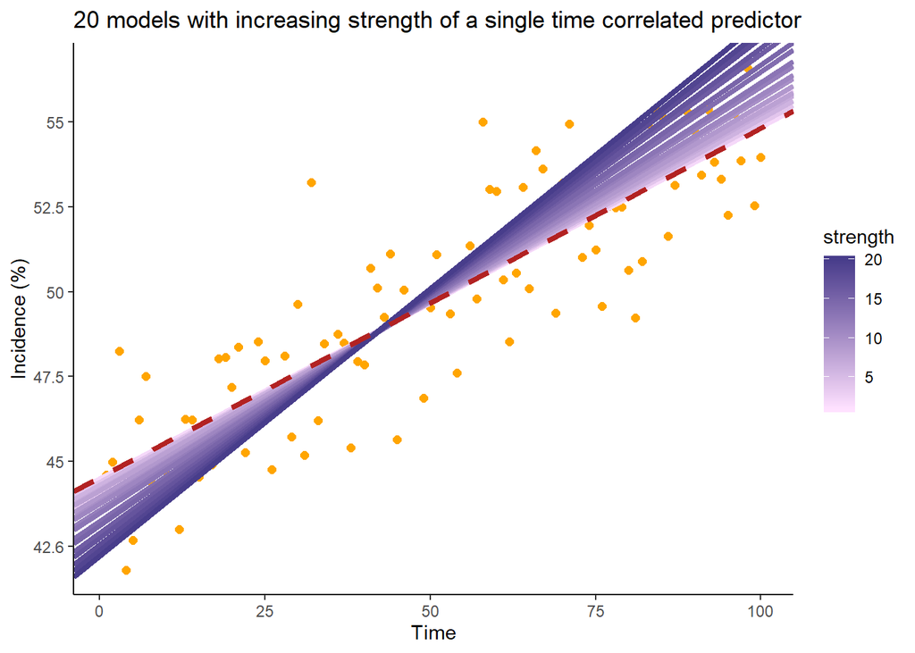

So that is a very controlled example where we’re just looking at the effect of one predictor and changing how strong its relationship is with both the outcome and time variable. In practice we’re likely to have many binary predictors of different incidences. Let’s try an example where we successively add in an additional predictor of 5% stronger relationship. This time we’ll randomly select the incidence of each predictor to get a feel for that as well.

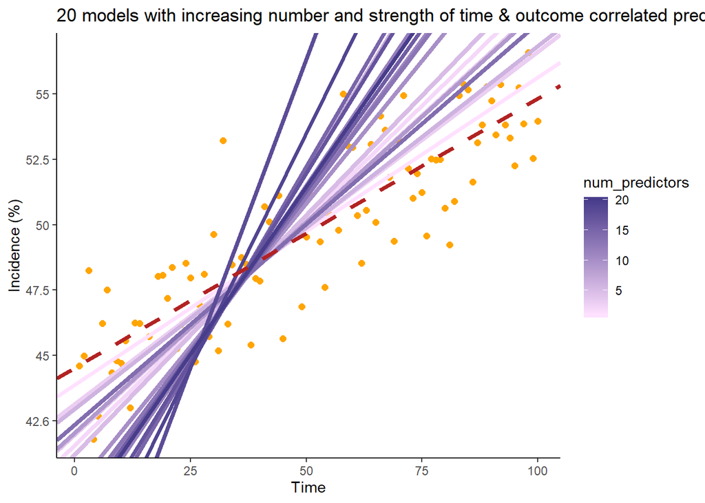

Here we can see some very ugly lines of best fit. These look even worse than the single predictor models and I interpret this is there being a cummulative effect as we add more predictors. The fact that the lines don’t fan out as uniformly is probably due to the fact that I sampled different incidences this time. This indicates that the incidence of the confounder variable also has an impact. I previously tried this experiment with some negatively correlated predictors as well and found that sometimes the effects pushed in opposite directions and the graph ended up not lookin too bad.

Hopefully I will have some time to look at this a bit more later but for now my takeaways are: 1. Binary predictors that are associated with only time or the outcome don’t affect the outcome much 2. Binary predictors that are associated with *both* time and the outcome really mess up graph 3. In practice, you will frequently have problems with this otherwise you wouldn’t adjust. At the moment I don’t have any remedy for this at the moment so I suspec that this method of plotting won’t work in general. 4. Marginal standardization should be used instead of prediction at the means.